← Gianni Hrousis / Portfolio

# Predicting Buying Decisions — Florence Books Online Book Club

Gianni Hrousis | MKT 326 | Lehigh University

2026-05-03

## 1. Load and Inspect the Data

```r
books <- read.csv("OnlineBookClub.csv", stringsAsFactors = FALSE)
dim(books)
```

```
## [1] 50000    16
```

```r
glimpse(books)
```

```
## Rows: 50,000
## Columns: 16
## $ acctnum   <int> 10001, 10002, 10003, 10004, 10005, 10006, 10007, 10008, 1000…
## $ gender    <chr> "M/NB", "M/NB", "F", "F", "F", "F", "M/NB", "M/NB", "F", "F"…
## $ first     <int> 49, 39, 19, 7, 15, 7, 25, 41, 65, 11, 7, 15, 13, 17, 25, 5, …
## $ last      <int> 29, 27, 15, 7, 15, 7, 25, 1, 5, 11, 5, 13, 13, 5, 25, 1, 7, …
## $ book_     <int> 109, 35, 25, 15, 15, 15, 15, 124, 130, 15, 25, 27, 15, 37, 1…
## $ nonbook_  <int> 248, 103, 147, 257, 134, 98, 0, 114, 288, 108, 269, 146, 211…
## $ total_    <int> 357, 138, 172, 272, 149, 113, 15, 238, 418, 123, 294, 173, 2…
## $ purch     <int> 10, 3, 2, 1, 1, 1, 1, 11, 11, 1, 2, 2, 1, 3, 1, 2, 3, 12, 2,…
## $ child     <int> 3, 0, 0, 0, 0, 0, 0, 2, 0, 0, 0, 0, 0, 0, 0, 2, 0, 4, 0, 0, …
## $ youth     <int> 2, 1, 0, 0, 0, 1, 0, 1, 2, 1, 1, 1, 0, 0, 0, 0, 0, 0, 0, 1, …
## $ cook      <int> 2, 0, 2, 0, 1, 0, 0, 2, 3, 0, 1, 0, 0, 2, 1, 0, 2, 6, 1, 1, …
## $ do_it     <int> 0, 1, 0, 0, 0, 0, 1, 3, 2, 0, 0, 0, 1, 0, 0, 0, 0, 0, 1, 0, …
## $ refernce  <int> 1, 0, 0, 1, 0, 0, 0, 0, 0, 0, 0, 1, 0, 1, 0, 0, 0, 0, 0, 0, …
## $ art       <int> 0, 0, 0, 0, 0, 0, 0, 0, 3, 0, 0, 0, 0, 0, 0, 0, 0, 2, 0, 0, …
## $ geog      <int> 2, 1, 0, 0, 0, 0, 0, 3, 1, 0, 0, 0, 0, 0, 0, 0, 1, 0, 0, 0, …
## $ subscribe <chr> "no", "no", "no", "no", "no", "yes", "no", "no", "yes", "no"…
```

The dataset contains **50000 customers** and **16 variables** covering offline purchase behavior and online book club subscription status.

## 2. SQL Descriptive Statistics

Using `sqldf` to replicate the SQL analyses required by the assignment.

### 2a. Key Summary Statistics

```r
sql_summary <- sqldf("
  SELECT
    ROUND(AVG(total_), 2)    AS avg_total_spend,
    ROUND(STDEV(total_), 2)  AS sd_total_spend,
    ROUND(AVG(purch), 2)     AS avg_books_purchased,
    ROUND(STDEV(purch), 2)   AS sd_books_purchased,
    ROUND(AVG(last), 2)      AS avg_months_since_last,
    ROUND(STDEV(last), 2)    AS sd_months_since_last
  FROM books
")

sql_summary %>%
  kable(caption = "Descriptive Statistics: Spend, Purchases, and Recency") %>%
  kable_styling(bootstrap_options = c("striped", "hover"), full_width = FALSE)
```

Descriptive Statistics: Spend, Purchases, and Recency

| avg_total_spend | sd_total_spend | avg_books_purchased | sd_books_purchased | avg_months_since_last | sd_months_since_last |
| --- | --- | --- | --- | --- | --- |
| 208.32 | 101.36 | 3.89 | 3.48 | 12.36 | 8.15 |

**Interpretation:** The average customer spent **$208.32** offline with a standard deviation of $101.36, indicating wide variation in customer value. Customers purchased an average of 3.89 books, and their last purchase was 12.36 months ago on average — meaning most customers are not recent shoppers.

### 2b. Subscription Rates by Gender

```r
gender_subs <- sqldf("
  SELECT
    gender,
    COUNT(*) AS total_customers,
    SUM(CASE WHEN subscribe = 'yes' THEN 1 ELSE 0 END) AS subscribers,
    ROUND(100.0 * SUM(CASE WHEN subscribe = 'yes' THEN 1 ELSE 0 END) / COUNT(*), 2) AS pct_subscribed
  FROM books
  GROUP BY gender
")

gender_subs %>%
  kable(caption = "Subscription Counts and Rates by Gender") %>%
  kable_styling(bootstrap_options = c("striped", "hover"), full_width = FALSE)
```

Subscription Counts and Rates by Gender

| gender | total_customers | subscribers | pct_subscribed |
| --- | --- | --- | --- |
| F | 33302 | 2389 | 7.17 |
| M/NB | 16698 | 2133 | 12.77 |

**Interpretation:** Male/NB customers subscribe at roughly **12.77%**, compared to **7.17%** for female customers — a meaningful gap that suggests gender is a relevant predictor for the logistic model.

### 2c. Overall Subscription Rate

```r
overall <- sqldf("
  SELECT
    SUM(CASE WHEN subscribe = 'yes' THEN 1 ELSE 0 END) AS total_subscribers,
    COUNT(*) AS total_customers,
    ROUND(100.0 * SUM(CASE WHEN subscribe = 'yes' THEN 1 ELSE 0 END) / COUNT(*), 2) AS pct_subscribed
  FROM books
")

overall %>%
  kable(caption = "Overall Subscription Rate") %>%
  kable_styling(bootstrap_options = c("striped", "hover"), full_width = FALSE)
```

Overall Subscription Rate

| total_subscribers | total_customers | pct_subscribed |
| --- | --- | --- |
| 4522 | 50000 | 9.04 |

## 3. Feature Engineering: IsFemale Dummy Variable

Dummy coding is necessary because regression models require numeric inputs; a raw “M/NB” / “F” string cannot be interpreted as a quantity.

```r
books <- books %>%
  mutate(
    IsFemale  = ifelse(gender == "F", 1, 0),
    subscribed = ifelse(subscribe == "yes", 1, 0)
  )

cat("IsFemale distribution:\n")
```

```
## IsFemale distribution:
```

```r
table(books$IsFemale)
```

```
##
##     0     1
## 16698 33302
```

## 4. Linear Regression: Predicting Total Offline Spend

**Dependent variable:** `total_` (total dollars spent in offline stores) **Independent variables:** `IsFemale`, `first` (months since first purchase), and all 7 book category counts

```r
lm_model <- lm(
  total_ ~ IsFemale + first + child + youth + cook + do_it + refernce + art + geog,
  data = books
)

summary(lm_model)
```

```
##
## Call:
## lm(formula = total_ ~ IsFemale + first + child + youth + cook +
##     do_it + refernce + art + geog, data = books)
##
## Residuals:
##      Min       1Q   Median       3Q      Max
## -153.021  -75.383   -0.288   75.390  151.728
##
## Coefficients:
##              Estimate Std. Error t value Pr(>|t|)
## (Intercept) 149.62753    0.95088 157.358   <2e-16 ***
## IsFemale      0.67856    0.86483   0.785    0.433
## first        -0.03351    0.03831  -0.874    0.382
## child        15.26421    0.42152  36.212   <2e-16 ***
## youth        15.41773    0.62667  24.603   <2e-16 ***
## cook         15.65582    0.40568  38.592   <2e-16 ***
## do_it        15.00801    0.58779  25.533   <2e-16 ***
## refernce     14.51158    0.69844  20.777   <2e-16 ***
## art          14.46004    0.63037  22.939   <2e-16 ***
## geog         15.18183    0.52843  28.730   <2e-16 ***
## ---
## Signif. codes:  0 '***' 0.001 '**' 0.01 '*' 0.05 '.' 0.1 ' ' 1
##
## Residual standard error: 86.87 on 49990 degrees of freedom
## Multiple R-squared:  0.2656, Adjusted R-squared:  0.2655
## F-statistic:  2009 on 9 and 49990 DF,  p-value: < 2.2e-16
```

```r
lm_coefs <- broom::tidy(lm_model) %>%
  mutate(
    estimate   = round(estimate, 3),
    std.error  = round(std.error, 3),
    statistic  = round(statistic, 3),
    p.value    = round(p.value, 4),
    significant = ifelse(p.value < 0.05, "Yes", "No")
  )

lm_coefs %>%
  kable(caption = "Linear Regression Coefficients — Total Offline Spend") %>%
  kable_styling(bootstrap_options = c("striped", "hover", "condensed"), full_width = FALSE) %>%
  column_spec(6, color = ifelse(lm_coefs$significant == "Yes", "green", "red"))
```

Linear Regression Coefficients — Total Offline Spend

| term | estimate | std.error | statistic | p.value | significant |
| --- | --- | --- | --- | --- | --- |
| (Intercept) | 149.628 | 0.951 | 157.358 | 0.0000 | Yes |
| IsFemale | 0.679 | 0.865 | 0.785 | 0.4327 | No |
| first | -0.034 | 0.038 | -0.874 | 0.3819 | No |
| child | 15.264 | 0.422 | 36.212 | 0.0000 | Yes |
| youth | 15.418 | 0.627 | 24.603 | 0.0000 | Yes |
| cook | 15.656 | 0.406 | 38.592 | 0.0000 | Yes |
| do_it | 15.008 | 0.588 | 25.533 | 0.0000 | Yes |
| refernce | 14.512 | 0.698 | 20.777 | 0.0000 | Yes |
| art | 14.460 | 0.630 | 22.939 | 0.0000 | Yes |
| geog | 15.182 | 0.528 | 28.730 | 0.0000 | Yes |

**Interpretation:**

- **Book categories** are the strongest predictors of spend. Each additional book purchased in any category adds roughly $14–16 to total spend, consistent with the idea that book purchases directly drive revenue.
- **IsFemale and first** are not statistically significant (p > 0.05), suggesting gender and customer tenure do not independently predict how much someone spends offline once purchase behavior is controlled for.
- **R² = 0.2656**: The model explains approximately 26.6% of the variance in total spend. An R² of 20–30% is typical for behavioral spend models where much of the variation is driven by unobserved individual factors (e.g., income, life stage, preferences). The goal here is directional inference — understanding *which* variables matter — rather than high-precision prediction.

## 5. Logistic Regression: Predicting Subscription

**Dependent variable:** `subscribed` (1 = subscribed, 0 = did not subscribe) **Independent variables:** recency (`last`), monetary (`total_`), `IsFemale`, and all 7 book categories

```r
logit_model <- glm(
  subscribed ~ last + total_ + IsFemale + child + youth + cook + do_it + refernce + art + geog,
  data   = books,
  family = binomial(link = "logit")
)

summary(logit_model)
```

```
##
## Call:
## glm(formula = subscribed ~ last + total_ + IsFemale + child +
##     youth + cook + do_it + refernce + art + geog, family = binomial(link = "logit"),
##     data = books)
##
## Coefficients:
##               Estimate Std. Error z value Pr(>|z|)
## (Intercept) -1.6001096  0.0520980 -30.713  < 2e-16 ***
## last        -0.0947124  0.0027924 -33.918  < 2e-16 ***
## total_       0.0011160  0.0001982   5.630 1.80e-08 ***
## IsFemale    -0.7607204  0.0357608 -21.272  < 2e-16 ***
## child       -0.1862162  0.0172824 -10.775  < 2e-16 ***
## youth       -0.1129745  0.0261087  -4.327 1.51e-05 ***
## cook        -0.2703210  0.0171283 -15.782  < 2e-16 ***
## do_it       -0.5391648  0.0269657 -19.994  < 2e-16 ***
## refernce     0.2346876  0.0265583   8.837  < 2e-16 ***
## art          1.1555840  0.0221439  52.185  < 2e-16 ***
## geog         0.5742763  0.0186311  30.824  < 2e-16 ***
## ---
## Signif. codes:  0 '***' 0.001 '**' 0.01 '*' 0.05 '.' 0.1 ' ' 1
##
## (Dispersion parameter for binomial family taken to be 1)
##
##     Null deviance: 30355  on 49999  degrees of freedom
## Residual deviance: 24122  on 49989  degrees of freedom
## AIC: 24144
##
## Number of Fisher Scoring iterations: 6
```

```r
logit_coefs <- broom::tidy(logit_model) %>%
  mutate(
    odds_ratio  = round(exp(estimate), 3),
    estimate    = round(estimate, 4),
    std.error   = round(std.error, 4),
    statistic   = round(statistic, 3),
    p.value     = round(p.value, 4),
    significant = ifelse(p.value < 0.05, "Yes", "No")
  ) %>%
  select(term, estimate, std.error, statistic, p.value, odds_ratio, significant)

logit_coefs %>%
  kable(caption = "Logistic Regression Coefficients and Odds Ratios — Subscription Likelihood") %>%
  kable_styling(bootstrap_options = c("striped", "hover", "condensed"), full_width = FALSE) %>%
  column_spec(7, color = ifelse(logit_coefs$significant == "Yes", "green", "red"))
```

Logistic Regression Coefficients and Odds Ratios — Subscription Likelihood

| term | estimate | std.error | statistic | p.value | odds_ratio | significant |
| --- | --- | --- | --- | --- | --- | --- |
| (Intercept) | -1.6001 | 0.0521 | -30.713 | 0 | 0.202 | Yes |
| last | -0.0947 | 0.0028 | -33.918 | 0 | 0.910 | Yes |
| total_ | 0.0011 | 0.0002 | 5.630 | 0 | 1.001 | Yes |
| IsFemale | -0.7607 | 0.0358 | -21.272 | 0 | 0.467 | Yes |
| child | -0.1862 | 0.0173 | -10.775 | 0 | 0.830 | Yes |
| youth | -0.1130 | 0.0261 | -4.327 | 0 | 0.893 | Yes |
| cook | -0.2703 | 0.0171 | -15.782 | 0 | 0.763 | Yes |
| do_it | -0.5392 | 0.0270 | -19.994 | 0 | 0.583 | Yes |
| refernce | 0.2347 | 0.0266 | 8.837 | 0 | 1.265 | Yes |
| art | 1.1556 | 0.0221 | 52.185 | 0 | 3.176 | Yes |
| geog | 0.5743 | 0.0186 | 30.824 | 0 | 1.776 | Yes |

## 6. Model Validation: ROC Curve and AUC

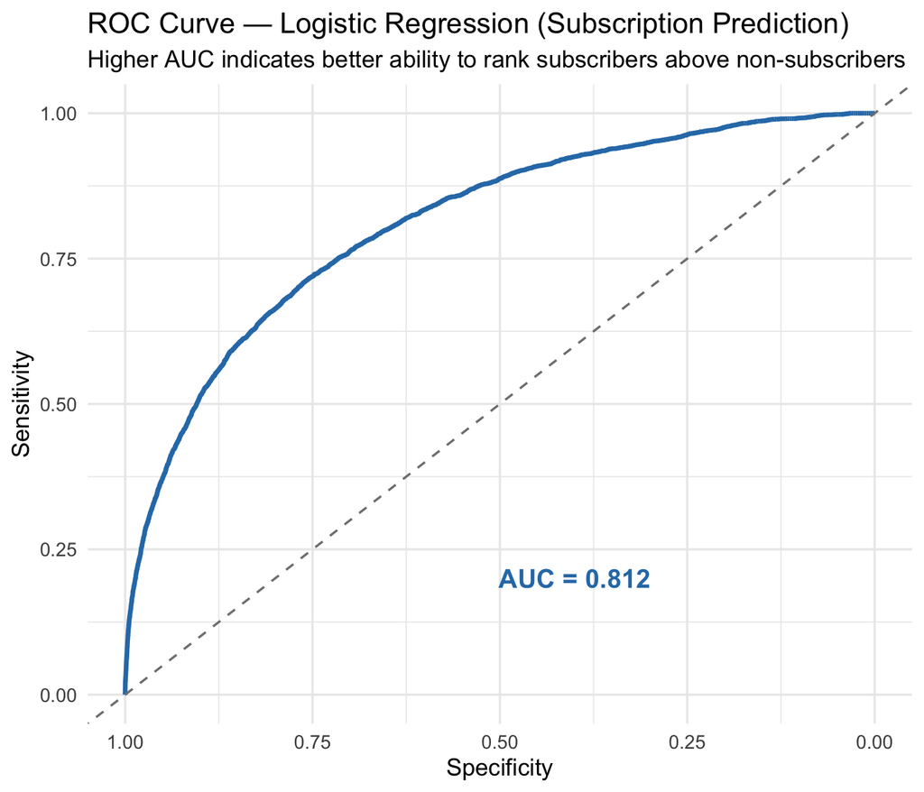

```r
books$pred_prob <- predict(logit_model, type = "response")

roc_obj <- roc(books$subscribed, books$pred_prob, quiet = TRUE)
auc_val <- auc(roc_obj)

ggroc(roc_obj, color = "#2c7bb6", linewidth = 1.2) +
  geom_abline(slope = 1, intercept = 1, linetype = "dashed", color = "gray50") +
  annotate("text", x = 0.4, y = 0.2,
           label = paste0("AUC = ", round(auc_val, 3)),
           size = 5, color = "#2c7bb6", fontface = "bold") +
  labs(
    title    = "ROC Curve — Logistic Regression (Subscription Prediction)",
    subtitle = "Higher AUC indicates better ability to rank subscribers above non-subscribers",
    x        = "Specificity",
    y        = "Sensitivity"
  ) +
  theme_minimal(base_size = 13)
```

**AUC = 0.812**: The model has strong discriminative ability. An AUC above 0.80 means the model correctly ranks a randomly chosen subscriber above a randomly chosen non-subscriber about 81% of the time. Given the class imbalance (9% positive rate), this is a meaningful result.

### Confusion Matrix (threshold = 0.5)

```r
pred_class <- ifelse(books$pred_prob >= 0.5, 1, 0)
cm <- confusionMatrix(factor(pred_class), factor(books$subscribed), positive = "1")
cm
```

```
## Confusion Matrix and Statistics
##
##           Reference
## Prediction     0     1
##          0 45126  3838
##          1   352   684
##
##                Accuracy : 0.9162
##                  95% CI : (0.9137, 0.9186)
##     No Information Rate : 0.9096
##     P-Value [Acc > NIR] : 8.683e-08
##
##                   Kappa : 0.2198
##
##  Mcnemar's Test P-Value : < 2.2e-16
##
##             Sensitivity : 0.15126
##             Specificity : 0.99226
##          Pos Pred Value : 0.66023
##          Neg Pred Value : 0.92162
##              Prevalence : 0.09044
##          Detection Rate : 0.01368
##    Detection Prevalence : 0.02072
##       Balanced Accuracy : 0.57176
##
##        'Positive' Class : 1
##
```

> **Note:** At a 0.5 threshold, the model’s sensitivity (ability to correctly identify subscribers) is low due to class imbalance — most customers are non-subscribers, so a conservative threshold misses many true positives. In practice, a lower threshold (e.g., 0.2–0.3) or decile-based targeting is more appropriate, which is what we apply in the next section.

## 7. Buying Prediction and Customer Profiling by Decile

```r
books <- books %>%
  mutate(decile = ntile(pred_prob, 10))

decile_summary <- books %>%
  group_by(decile) %>%
  summarise(
    n_customers       = n(),
    avg_pred_prob     = round(mean(pred_prob), 4),
    actual_sub_rate   = round(mean(subscribed), 4),
    avg_recency       = round(mean(last), 1),
    avg_monetary      = round(mean(total_), 2),
    avg_art_books     = round(mean(art), 2),
    avg_diy_books     = round(mean(do_it), 2),
    pct_female        = round(mean(IsFemale) * 100, 1)
  ) %>%
  arrange(desc(decile))

decile_summary %>%
  kable(caption = "Decile Profiling — Predicted vs. Actual Subscription Rates") %>%
  kable_styling(bootstrap_options = c("striped", "hover", "condensed"), full_width = FALSE) %>%
  row_spec(1, bold = TRUE, background = "#eaf4fb") %>%   # top decile
  row_spec(10, bold = TRUE, background = "#fdecea")       # bottom decile
```

Decile Profiling — Predicted vs. Actual Subscription Rates

| decile | n_customers | avg_pred_prob | actual_sub_rate | avg_recency | avg_monetary | avg_art_books | avg_diy_books | pct_female |
| --- | --- | --- | --- | --- | --- | --- | --- | --- |
| 10 | 5000 | 0.3856 | 0.3870 | 7.2 | 257.35 | 1.50 | 0.47 | 41.9 |
| 9 | 5000 | 0.1638 | 0.1672 | 8.0 | 224.87 | 0.75 | 0.39 | 49.1 |
| 8 | 5000 | 0.1049 | 0.1022 | 8.6 | 214.23 | 0.48 | 0.37 | 54.9 |
| 7 | 5000 | 0.0741 | 0.0736 | 8.8 | 207.64 | 0.30 | 0.34 | 63.2 |
| 6 | 5000 | 0.0556 | 0.0568 | 9.6 | 199.11 | 0.22 | 0.37 | 69.8 |
| 5 | 5000 | 0.0423 | 0.0392 | 10.9 | 199.13 | 0.16 | 0.39 | 72.8 |
| 4 | 5000 | 0.0321 | 0.0278 | 12.4 | 191.33 | 0.13 | 0.42 | 77.9 |
| 3 | 5000 | 0.0237 | 0.0242 | 14.4 | 191.57 | 0.11 | 0.45 | 81.3 |
| 2 | 5000 | 0.0157 | 0.0180 | 17.9 | 193.61 | 0.13 | 0.65 | 77.0 |
| 1 | 5000 | 0.0065 | 0.0084 | 25.9 | 204.34 | 0.07 | 0.77 | 78.2 |

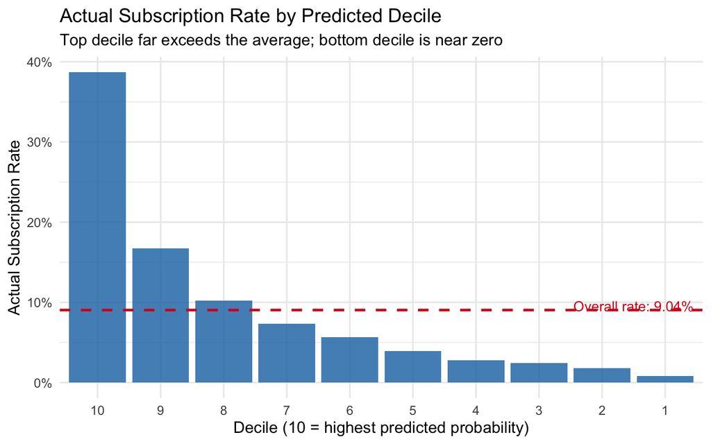

```r
decile_summary %>%
  ggplot(aes(x = factor(decile, levels = rev(levels(factor(decile)))), y = actual_sub_rate)) +
  geom_col(fill = "#2c7bb6", alpha = 0.85) +
  geom_hline(yintercept = overall$pct_subscribed / 100, linetype = "dashed", color = "#d7191c", linewidth = 1) +
  annotate("text", x = 9.5, y = overall$pct_subscribed / 100 + 0.005,
           label = paste0("Overall rate: ", overall$pct_subscribed, "%"),
           color = "#d7191c", size = 4) +
  scale_y_continuous(labels = percent_format()) +
  labs(
    title    = "Actual Subscription Rate by Predicted Decile",
    subtitle = "Top decile far exceeds the average; bottom decile is near zero",
    x        = "Decile (10 = highest predicted probability)",
    y        = "Actual Subscription Rate"
  ) +
  theme_minimal(base_size = 13)
```

**Bottom decile profile (decile 1 — lowest predicted subscribers):** - Lapsed buyers, moderate spend - High DIY and cookbook activity, minimal art books - Predominantly Female - **Actual subscription rate ≈ 0.84%** — near zero

**Recommendation:** Target the top 2 deciles for conversion campaigns (high ROI, high predicted probability). Target deciles 4–7 for reactivation and awareness campaigns. Do not invest in the bottom 3 deciles — the model predicts near-zero probability of subscription.

## 8. Email Campaign Design

Based on the logistic model and decile profiling, here is a recommended email campaign to drive online book club subscriptions.

**Target audience:** - **Tier 1 (conversion):** Top 2 deciles (~10,000 customers) — recent, art/geography book buyers, Male/NB skewing. High ROI. - **Tier 2 (nurture):** Deciles 4–7 (~20,000 customers) — moderate probability; need an activation nudge.

**Subject lines:** - Tier 1: *“Your next read is waiting — unlock 2 visual e-books this month”* - Tier 2: *“Because you loved [last purchase], here’s something new”* (personalized dynamic insert)

**Email content:** - Hero image: visual preview of this month’s e-books, emphasizing rich illustration/photography (appeals to art/geography buyers). - One-sentence value proposition: *“Two beautifully illustrated e-books every month, curated to match your taste.”* - CTA: *“Start my free trial”*

**Timing:** - Send 3–4 weeks after a customer’s last offline purchase, when recency is still positive but urgency is rising. - Day: Tuesday or Wednesday morning. - Avoid sending to customers whose last purchase was more than 18 months ago (bottom 3 deciles — low ROI).

**Marketing metrics to track:** - Open rate (target ≥ 22%) - Click-through rate (target ≥ 3.5%) - Conversion rate: trial sign-ups per email sent - 30-day retention: % of trial users who convert to paid subscription - Decile lift by campaign wave (validate that top-decile targeting continues to outperform)